# Rolv Desktop Documentation (v1.0.0)

2025-05-12

[figure not shown]

# Introduction to rolv desktop app

Rolv is an AI-powered research assistant designed specifically for the life sciences field. It helps researchers streamline and accelerate tasks such as data analysis, literature review, and hypothesis generation by combining advanced AI tools with access to scientific databases and human expertise.

## ✨ Core features

- **AI-Assisted Data Analysis**: Ask data analysis questions, rolv desktop is integrated with your data (e.g., *“Give me differentially expressed genes in this file and plot a heatmap”*).
- **Local Data Analysis**: Your data stays secure on your device—no cloud dependency for analysis.
- **PubMed integration**: Get PubMed backed answers to your queries. (e.g., *“What are the binding partners of TGFbeta ?”*).
- **Dataset Search Integration**: Find the relevant datasets you need for your analysis. (e.g., *“Give me TGFbeta ChIP-seq datasets ?”*).
- **Create AI-Assisted Analysis Workflows**: Data analysis is not linear; build complex workflows using the graph interface.
- **Ask A Human Feature**: AI gets you far, but sometimes you need human expertise. When you’re stuck, connect with data analysis experts through our platform.

## 📥 How to get access

Without having access to rolv platform online you won’t be able to use the rolv desktop app. - Request access to the platform here https://www.rolv.io/access - Download the Rolv desktop app and start analyzing. See releases [here](https://github.com/rolv-io/rolvapp/releases).

## Who is the app for

The **Rolv app** is designed for **life science researchers and professionals** who work with complex biological data and need to streamline their research workflows. This includes:

- **Molecular biologists and geneticists** analyzing gene expression, ChIP-seq, or other omics data.
- **Bioinformaticians** who want to accelerate data processing and workflow design using AI tools.
- **Biomedical researchers** conducting literature reviews or exploring disease mechanisms.
- **Academic scientists and PhD students** looking to quickly extract insights from data and literature.
- **Biotech and pharma R&D teams** that need secure, local data analysis with expert support when needed.

It’s ideal for users who want the power of AI but require **data privacy, scientific rigor, and integration with existing research tools**.

## Supported Platforms

Rolv desktop app is available on the following operating systems:

- **Windows 11**
- **macOS X**
- **Ubuntu (latest LTS versions)**
- **Fedora (latest stable release)**

> **Note**: Rolv is **not supported** on Windows 10 or earlier, other Linux distributions, or mobile platforms (iOS/Android).

# Installation Instructions

## System Requirements

Any hardware that is able to run a recent chrome browser should be able to run the desktop app. However for smooth performance we have the following reccomnedations:

- **CPU**: Multi-core processor (2 GHz+).
- **RAM**: 8 GB+ for resource-heavy apps (e.g., IDEs, communication tools).
- **Storage**: SSD for faster load times (1 GB free storage)
- **Internet connection**: Required as the app relies on web APIs for certain services.

## Install the dependencies

Currently, the only external dependency that that doesn’t come with the app is **R**. R is a free, open-source programming language and software environment primarily used for statistical computing and data analysis. Currently, we need this depency to perform data analysis tasks. If you already have R installed, you can skip this step. It is probably a good idea to use a latest version of R though.

### How to install R

#### Windows 11

To install R on a Windows system, follow these steps:

1. Download R
- Go to the official R project website: https://cran.r-project.org.
- Click on the “Download R for Windows” link.
- On the next page, click “base” (this is the standard R installation).
- Click “Download R X.X.X for Windows” (the version number will vary, but it’s the latest version).
2. Install R
- After the `.exe` file is downloaded, double-click it to begin the installation.
- Follow the installation prompts. You can typically accept the default settings, but here are some key options:
  - Select components: You can usually keep the default components selected.
  - Installation location: You can leave it at the default path unless you want to change it.
  - Start Menu folder: You can leave this as the default, or change it.
- Once you’ve selected your options, click **Next** and then **Install**.
3. Complete Installation
- Once the installation is complete, click **Finish**.
- You should now have R installed on your Windows machine.
4. Verify the Installation
- You can open R by searching for R in the Start Menu or by finding it in the folder where you installed it.

#### Mac OS

To install R on a Mac system, follow these steps:

1. Go to the official R website: https://cran.r-project.org.
- Click on “Download R for macOS”.
- Choose the latest .pkg file under “Latest release” and download it.
2. Install R
- Open the downloaded .pkg file.
- Follow the on-screen installation instructions.
3. Verify the Installation R should now be installed on your device. To verify its installation, open the terminal (Cmd + Space, type in terminal and press Enter). In the terminal, run the following command:

```bash
R--version
```

If installed correctly, it will display the installed R version.

#### Ubuntu

To install R on Ubuntu, we first open the terminal. This can be done by pressing Ctrl + Alt + T or by searching for ‘Terminal’ in your applications menu. After opening the terminal, run the following commands:

1. Update your package list (to make sure you are getting the latest version of packages):

```bash
sudo apt update
```

2. Install the dependencies (this step ensures you have the necessary packages for R):

```bash
sudo apt install -y software-properties-common
```

3. Add the R repository (this will allow you to install the latest version of R):

```bash
sudo add-apt-repository ppa:marutter/rrutter4.0
```

4. Update the package list again to include the new repository:

```bash
sudo apt update
```

5. Install R:

```bash
sudo apt install -y r-base
```

If all went well, R should now be installed. Check the installation by typing:

```bash
R --version
```

This will show the installed version of R, confirming it’s been set up correctly. Alternatively, you can follow the steps given on https://cloud.r-project.org It is important to also install some dependencies for RolvDesktop (if they are not yet already preinstalled). For this run:

```bash
sudo apt install -y libmagick++-dev imagemagick
sudo apt install -y libpoppler-cpp-dev
```

#### Fedora

To install R on Fedora, we first open the terminal. This can be done by pressing Ctrl + Alt + T or by searching for ‘Terminal’ in your applications menu. After opening the terminal, run the following commands:

```bash
sudo dnf install -y libcurl-devel libxml2-devel openssl-devel
sudo dnf install -y R
```

After running these commands, R should be installed on your system. You can check this by typing:

```bash
R --version
```

Alternatively, you can follow the steps given on https://cloud.r-project.org It is important to also install some dependencies for RolvDesktop (if they are not yet already preinstalled). For this run:

```bash
sudo dnf install -y ImageMagick ImageMagick-devel ImageMagick-c++-devel
sudo dnf install -y poppler-cpp poppler-devel
sudo dnf install qpdf-devel
```

## Installing the app

Once R is installed, we’re ready to install *rolv* desktop app

### Windows 11

For windows installation, you should download a file named **rolvdesktop-1.0.0 Setup.exe**.Now, let’s walk through the steps to install *rolv* desktop app:

1. Locate the **rolvdesktop-1.0.0 Setup.exe** file on your computer.
2. Double-click the .exe file. This should start the installation process.
3. Once the installation is complete, *rolv* desktop app should open automatically.
4. The app can now be found in:

```bash
C:\Users\YourUser\AppData\Local\rolvdesktop
```

Congratulations! You’ve successfully installed *rolv* desktop app! Now you’re all set to start using the app. You can move on to the next chapter, where we will dive deeper into the features and how to navigate the *rolv* desktop app interface. Enjoy exploring!

#### Mac OS

For mac os, you should download the file called `rolvdesktop-darwin-x64-1.0.0.zip`. Afterwards, follow the steps below:

1. Move the rolvdesktop-darwin-x64-1.0.0.zip file to the directory where you want it to be installed.
2. Double-click the .zip file to extract it.
3. The RolvDesktop should now appear.

Congratulations! You’ve successfully installed *rolv* desktop app! Now you’re all set to start using the app. You can move on to the next chapter, where we will dive deeper into the features and how to navigate the *rolv* desktop app interface. Enjoy exploring!

### Ubuntu

Once R is installed, we’re ready to install *rolv* desktop app. You should download a file named rolvdesktop_1.0.0_amd64.deb. Now, let’s walk through the steps to install *rolv* desktop app:

1. Open the terminal ( press Ctrl + Alt + T or search for ‘Terminal’ in your applications menu)
2. Move to the directory in which you downloaded rolvdesktop_1.0.0_amd64.deb. This can be done by:

```bash
cd /path/to/directory/
```

3. Run the following command and fill in your system password:

```bash
sudo apt install ./rolvdesktop_1.0.0_amd64.deb
```

After this, RolvDesktop should be installed! You can open the app by searching for ‘rolvdesktop’ in your applications menu, or by running the following command in the Terminal:

```bash
rolvdesktop
```

Congratulations! You’ve successfully installed RolvDesktop! Now you’re all set to start using the app. You can move on to the next chapter, where we will dive deeper into the features and how to navigate the RolvDesktop interface. Enjoy exploring!

### Fedora

Once R is installed, we’re ready to install RolvDesktop. You should download a file named **rolvdesktop-1.0.0-1.x86_64.rpm**.Now, let’s walk through the steps to install RolvDesktop:

1. Open the terminal ( press Ctrl + Alt + T or search for ‘Terminal’ in your applications menu)
2. Move to the directory in which you downloaded **rolvdesktop-1.0.0-1.x86_64.rpm**. This can be done by:

```bash
cd /path/to/directory/
```

3. Run the following command and fill in your system password:

```bash
sudo rpm -ivh ./rolvdesktop-1.0.0-1.x86_64.rpm
```

After this, RolvDesktop should be installed! You can open the app by searching for ‘rolvdesktop’ in your applications menu, or by running the following command in the Terminal:

```bash
rolvdesktop
```

Congratulations! You’ve successfully installed RolvDesktop! Now you’re all set to start using the app. You can move on to the next chapter, where we will dive deeper into the features and how to navigate the RolvDesktop interface. Enjoy exploring!

# Starting the app and post-installation verification

Now that we have all the prerequisites installed, we can start playing around with RolvDesktop! If you have trouble opening the app because of security reasons, follow the steps below:

- **For Mac users:** Right-click on the app’s icon and then select “Open” from the menu. A security warning will appear, but this time it will give you the option to “Open” the app anyway. Click this option.
- **For Linux users:** Right-click on the app’s icon and look for “Run as Administrator” or “Run as Root”. Click this option. The app should now open.
- **For Windows users:** Right-click on the app’s icon and look for “Run as Administrator”. Click this option. The app should now open.

Once the app is opened, the first thing to do is to log in with your username and password! Fill in, and press the login button. If you have a valid account, you should now be logged in and see the chat screen. If you don’t have access to the platform please see the section called 📥 How to get access.

## login window

Here is how the login window looks like:

[figure not shown]

## Testing if R works

The next step is to let RolvDesktop know where it can find your R installment! A default path has already been set for you, but this might not be the correct one.

To check if the app can find your R installation, click Set R path in the Menu Bar. Then, by clicking Test R path, we can see if RolvDesktop can find your R installation. If R is available, you should see a popup on the right side of the screen telling you that R is working.

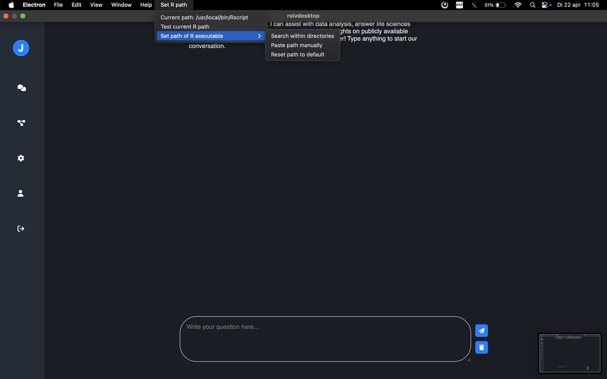

setting up and checking R path

## If R is not Available or can not be found

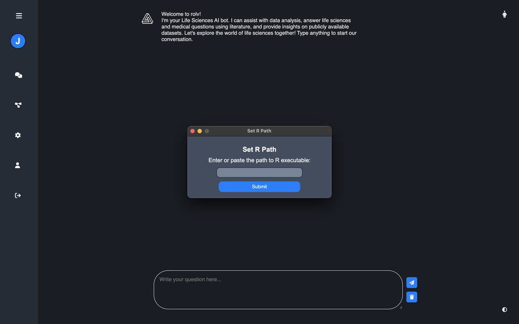

If this is the case, follow these steps to determine where your R resides in your system:

1. First, we open up the terminal/PowerShell:
- On Mac: Press Cmd + Space, type in Terminal, and press Enter.
- On Linux: Press Ctrl + Alt + T to open the terminal.
- On Windows: open PowerShell by pressing Win + X and selecting Windows PowerShell.
2. Now, we look for the Rscript file within the system:
   - On Mac/Linux type in the following command:

     `whereis Rscript`

     This should return the location of Rscript. Copy this path so we can paste this path into RolvDesktop.
   - On Windows type in the following command:

     ```r
     Get-ChildItem-Path C:\-Recurse-Filter "Rscript.exe"-ErrorAction SilentlyContinue
     ```

     This should return the location of Rscript. However, we cannot just paste the path in there as is. Ensure that the C: is deleted, and all the backslashes are changed to forward slases / before pasting the path in the app.

Once you have located the path of Rscript, we can now let RolvDesktop know. To set the R path, go to Set R path in the Menu bar. Then, press set path of R ececutable and select paste path manually. A pop-up should now appear where you can paste the the path to Rscript. Paste the path to Rscript, click submit, and now R should be available to RolvDesktop! You can check this by pressing Test R path again.

If everthing is OK, you should now be able to see the main interface and should be able to start your journey.

[figure not shown]

chat interface

# Configuration & Preferences

# Usage Guide

## How to use the basic chat interface

To give you an example of the basic usage, we ask the bot to simulate data and do some basic analysis. Here is how it would look like:

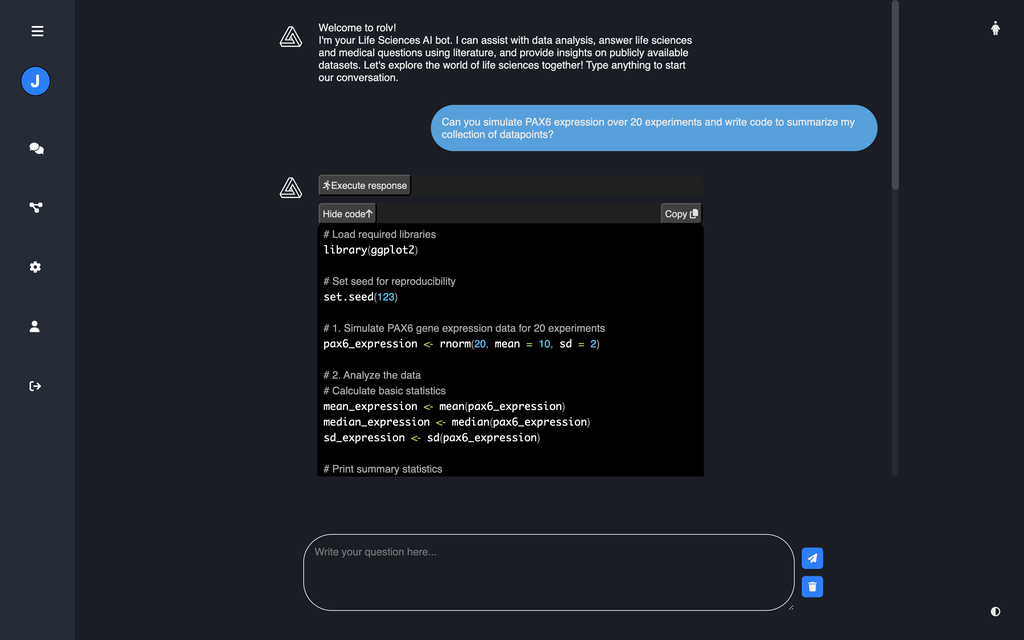

And here is the result of the simulation and analysis:

[figure not shown]

## AI-assited workflow creation

# FAQs & Troubleshooting

## How do I update the app?

The new versions are released via github releases. The app will check if there are new versions available everytime you start it.

## Does it work offline?

The app can not work offline as it requires connection to chat API.

## How to uninstall?

Here’s how to uninstall Electron-based apps on **Windows 11**, **macOS**, **Fedora**, and **Ubuntu**:

### **Windows 11**

#### **Method 1: Via Settings**

1. Open **Settings** (Win + I).
2. Go to **Apps → Installed Apps**.
3. Search for the RolvDesktop
4. Click the **⋮ (three dots)** next to the app → **Uninstall**.

#### **Method 2: Control Panel**

1. Open **Control Panel** → **Programs → Programs and Features**.
2. Right-click the app → **Uninstall**.

### **macOS**

#### **Method 1: Drag to Trash**

1. Open **Finder** → Go to **Applications**.
2. Drag the app to the **Trash** (or right-click → **Move to Trash**).
3. Empty the Trash.

#### **Method 2: Terminal**

```bash
sudo rm -rf /Applications/RolvDesktop.app
```

### **Fedora (Linux)**

#### **Method 1: If Installed via Package Manager (dnf/rpm)**

1. List installed packages:

   ```bash
   dnf list --installed | grep -i "RolvDesktop"
   ```

2. Uninstall:

   ```bash
   sudo dnf remove RolvDesktop
   ```

### **Ubuntu (Linux)**

#### **Method 1: If Installed via APT/.deb**

1. List installed packages:

   ```bash
   apt list --installed | grep -i "RolvDesktop"
   ```

2. Uninstall:

   ```bash
   sudo apt purge RolvDesktop
   ```

#### **Method 2: If Installed Manually (e.g., AppImage or .deb)**

- **AppImage**: Delete the file.
- **.deb**:

  ```bash
  sudo dpkg -r <package-name>
  ```

# Support & Feedback

## Contact: Email, forum, or GitHub link for support.

General contact: hello@rolv.io

Community forum: https://github.com/rolv-io/rolvapp/discussions/

## Bug Reports:

You can open bug reports here: https://github.com/rolv-io/rolvapp/issues

Please include screenshots and a detailed account of what’s happening as well as toy data and prompts that reproduces the problem. Otherwise, we can’t help you.

## Feature Requests: Process for suggesting improvements.

You can request features or share your ideas here: https://github.com/rolv-io/rolvapp/discussions/categories/ideas-feature-requests

# Updates & Maintenance

Auto-Update: App checks if there are new versions every time you restart it. It is advised to keep an up-to-date version.

Manual Update: You can also check latest releases manually and update your app.

# Documentation for older versions